# Agoda Case Testing

###### #

```python
exA.groupby([exA['booking_month']]).mean().iloc[:, [1]]
exB.groupby([exB['booking_month']]).mean().iloc[:, [1]]
exC.groupby([exC['booking_month']]).mean().iloc[:, [1]]
exD.groupby([exD['booking_month']]).mean().iloc[:, [1]]
exE.groupby([exE['booking_month']]).mean().iloc[:, [1]]
# This shows the according to different booking month, the average ADR,
```

| booking_month | ADR_USD |
| --- | --- |
| 8 | 109.198550 |
| 9 | 110.826204 |
| 10 | 99.963093 |
| 11 | 97.994114 |
| 12 | 99.187117 |

| booking_month | ADR_USD |
| --- | --- |
| 8 | 171.681678 |
| 9 | 134.966002 |
| 10 | 112.218616 |
| 11 | 115.132514 |
| 12 | 117.272491 |

| booking_month | ADR_USD |
| --- | --- |
| 8 | 262.300861 |
| 9 | 225.826890 |
| 10 | 221.957653 |
| 11 | 223.444868 |
| 12 | 224.002664 |

| booking_month | ADR_USD |
| --- | --- |
| 8 | 198.110619 |
| 9 | 211.860018 |
| 10 | 212.867046 |
| 11 | 221.493098 |
| 12 | 232.778977 |

| booking_month | ADR_USD |
| --- | --- |
| 8 | 111.140738 |
| 9 | 151.695746 |
| 10 | 139.237344 |
| 11 | 128.232725 |
| 12 | 160.108523 |

```python
exA.groupby([exA['checkin_month']]).mean().iloc[:, [1, 6]]
exB.groupby([exB['checkin_month']]).mean().iloc[:, [1, 6]]
exC.groupby([exC['checkin_month']]).mean().iloc[:, [1, 6]]
exD.groupby([exD['checkin_month']]).mean().iloc[:, [1, 6]]
exE.groupby([exE['checkin_month']]).mean().iloc[:, [1, 6]]
```

| checkin_month | ADR_USD | bookdays_int |
| --- | --- | --- |
| 10 | 100.946781 | 12.019395 |
| 11 | 99.527142 | 13.442493 |
| 12 | 101.046473 | 14.213453 |

| checkin_month | ADR_USD | bookdays_int |
| --- | --- | --- |
| 10 | 116.339792 | 12.591460 |
| 11 | 108.699471 | 12.980782 |
| 12 | 128.936437 | 15.992899 |

| checkin_month | ADR_USD | bookdays_int |
| --- | --- | --- |
| 10 | 220.981385 | 19.057406 |
| 11 | 212.940606 | 20.889217 |
| 12 | 238.112597 | 21.814815 |

| checkin_month | ADR_USD | bookdays_int |
| --- | --- | --- |
| 10 | 217.392117 | 14.127887 |
| 11 | 210.230484 | 14.607465 |
| 12 | 227.993227 | 16.616772 |

| checkin_month | ADR_USD | bookdays_int |
| --- | --- | --- |
| 10 | 143.920543 | 9.895215 |
| 11 | 120.648375 | 11.023121 |
| 12 | 153.772868 | 12.415857 |

```python
# Add the checkin date's day of week column
exB['day_of_week'] = exB['checkin_date'].dt.day_name()
exB.head()
# for date in exB['checkin_date']:
#     print(date.weekday())
```

|  | # | ADR_USD | hotel_id | city_id | star_rating | accommadation_type_name | chain_hotel | booking_date | checkin_date | checkout_date | booked_days_ahead | bookdays_int | booking_month | checkin_month | day_of_week |
| --- | --- | --- | --- | --- | --- | --- | --- | --- | --- | --- | --- | --- | --- | --- | --- |
| 0 | 1 | 89.860000 | 861894 | 17193 | 3.0 | Resort | non-chain | 2016-08-04 | 2016-10-01 | 2016-10-03 | 58 days | 58 | 8 | 10 | Saturday |
| 1 | 2 | 459.348000 | 195300 | 17193 | 5.0 | Resort | non-chain | 2016-08-05 | 2016-10-03 | 2016-10-06 | 59 days | 59 | 8 | 10 | Monday |
| 2 | 3 | 183.633333 | 770 | 17193 | 4.0 | Hotel | chain | 2016-08-07 | 2016-10-01 | 2016-10-04 | 55 days | 55 | 8 | 10 | Saturday |
| 3 | 4 | 191.280000 | 3644 | 17193 | 5.0 | Resort | chain | 2016-08-08 | 2016-10-07 | 2016-10-08 | 60 days | 60 | 8 | 10 | Friday |
| 4 | 5 | 54.860000 | 2030338 | 17193 | 3.0 | Hotel | non-chain | 2016-08-08 | 2016-10-02 | 2016-10-03 | 55 days | 55 | 8 | 10 | Sunday |

```python
exB.groupby([exB['booking_month'], exB['day_of_week'], exB['accommadation_type_name']]).mean().iloc[:, [1,4,5]]
```

| booking_month | day_of_week | accommadation_type_name | ADR_USD | star_rating | bookdays_int |
| --- | --- | --- | --- | --- | --- |
| 8 | Friday | Hotel | 287.580000 | 4.000000 | 59.000000 |
|  |  | Resort | 166.533333 | 4.200000 | 51.700000 |
|  |  | Resort Villa | 172.540000 | 3.500000 | 47.500000 |
|  | Monday | Hotel | 121.893333 | 3.666667 | 42.666667 |
|  |  | Resort | 272.416800 | 4.100000 | 49.200000 |
|  | Saturday | Guest House / Bed & Breakfast | 104.602667 | 2.200000 | 45.600000 |
|  |  | Hotel | 101.525556 | 3.500000 | 45.083333 |
|  |  | Resort | 175.465000 | 3.666667 | 49.583333 |
|  |  | Resort Villa | 243.510000 | 3.666667 | 44.666667 |
|  | Sunday | Guest House / Bed & Breakfast | 82.090000 | 3.000000 | 43.500000 |
|  |  | Hotel | 109.716667 | 3.333333 | 53.833333 |
|  |  | Private Villa | 362.180000 | 4.000000 | 47.000000 |
|  |  | Resort | 225.385000 | 3.875000 | 45.125000 |
|  |  | Resort Villa | 333.906667 | 3.666667 | 42.666667 |
|  | Thursday | Bungalow | 80.560000 | 3.000000 | 41.000000 |
|  |  | Guest House / Bed & Breakfast | 54.693333 | 2.500000 | 52.250000 |
|  |  | Hotel | 104.727407 | 3.666667 | 48.666667 |
|  |  | Resort | 100.166667 | 3.714286 | 47.428571 |
|  |  | Resort Villa | 172.200000 | 3.000000 | 52.000000 |
|  | Tuesday | Guest House / Bed & Breakfast | 94.120000 | 3.000000 | 41.000000 |
|  |  | Hotel | 64.580000 | 4.000000 | 44.000000 |
|  |  | Resort | 184.724000 | 3.800000 | 51.000000 |
|  | Wednesday | Hotel | 74.080000 | 3.333333 | 49.000000 |
|  |  | Resort | 489.764444 | 4.500000 | 50.500000 |
|  |  | Resort Villa | 228.600000 | 4.000000 | 58.000000 |
| 9 | Friday | Apartment | 257.500000 | 4.000000 | 15.000000 |
|  |  | Bungalow | 94.100000 | 3.000000 | 35.000000 |
|  |  | Guest House / Bed & Breakfast | 50.435000 | 2.000000 | 30.300000 |
|  |  | Hotel | 114.254917 | 3.537500 | 31.025000 |
|  |  | Resort | 133.206127 | 3.676471 | 33.029412 |
| ... | ... | ... | ... | ... | ... |
| 12 | Saturday | Hotel | 120.064194 | 3.521505 | 5.107527 |
|  |  | Resort | 146.516623 | 3.710526 | 5.763158 |
|  |  | Resort Villa | 155.428125 | 3.250000 | 9.187500 |
|  | Sunday | Bungalow | 62.056000 | 2.800000 | 7.000000 |
|  |  | Guest House / Bed & Breakfast | 53.023077 | 1.923077 | 4.615385 |
|  |  | Holiday Park / Caravan Park | 74.630000 | 2.000000 | 1.000000 |
|  |  | Hotel | 92.308627 | 3.264706 | 5.745098 |
|  |  | Resort | 104.120476 | 3.653061 | 4.795918 |
|  |  | Resort Villa | 178.889524 | 3.857143 | 6.000000 |
|  |  | Serviced Apartment | 21.800000 | 2.000000 | 2.000000 |
|  | Thursday | Apartment | 176.470000 | 3.000000 | 10.000000 |
|  |  | Bungalow | 80.257500 | 2.000000 | 1.625000 |
|  |  | Guest House / Bed & Breakfast | 42.078000 | 2.300000 | 5.900000 |
|  |  | Hostel | 13.400000 | 1.000000 | 0.000000 |
|  |  | Hotel | 93.103019 | 3.556604 | 4.094340 |
|  |  | Resort | 117.537986 | 3.791667 | 6.500000 |
|  |  | Resort Villa | 157.257551 | 3.428571 | 9.714286 |
|  | Tuesday | Apartment | 94.180000 | 3.000000 | 10.000000 |
|  |  | Bungalow | 61.684000 | 2.400000 | 3.800000 |
|  |  | Guest House / Bed & Breakfast | 60.130556 | 2.500000 | 8.000000 |
|  |  | Hostel | 14.060000 | 2.000000 | 3.000000 |
|  |  | Hotel | 83.675379 | 3.534091 | 4.431818 |
|  |  | Resort | 109.991667 | 3.720000 | 5.320000 |
|  |  | Resort Villa | 179.510000 | 3.500000 | 1.000000 |
|  | Wednesday | Bungalow | 66.370000 | 2.500000 | 8.000000 |
|  |  | Guest House / Bed & Breakfast | 47.758889 | 2.333333 | 2.222222 |
|  |  | Hotel | 94.561771 | 3.484375 | 6.156250 |
|  |  | Resort | 145.408889 | 3.809524 | 4.071429 |
|  |  | Resort Villa | 329.408750 | 3.625000 | 10.125000 |
|  |  | Serviced Apartment | 17.380000 | 2.000000 | 9.000000 |

230 rows × 3 columns

```python
exA.groupby([exA['day_of_week'], exA['accommadation_type_name']]).mean().iloc[:, [1, 4, 6]]
# Let's only look at the "Hotel" type, since we already know that the majority of records belongs to "hotel" in City A (82.26%)
exA_hotel = exA[exA['accommadation_type_name'] == 'Hotel']
exA_week = exA_hotel.groupby([exA['day_of_week']]).mean().iloc[:, [1, 4, 7]].sort_index()
exA_week = exA_week.iloc[:, [0]].sort_values(by = 'ADR_USD', ascending=False)
exA_week
```

| day_of_week | ADR_USD |
| --- | --- |
| Friday | 110.088949 |
| Saturday | 109.838897 |
| Thursday | 109.225913 |
| Monday | 103.224777 |
| Wednesday | 102.752676 |
| Sunday | 100.743228 |
| Tuesday | 100.065832 |

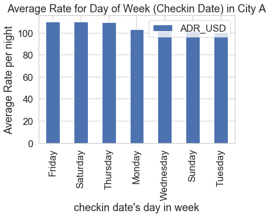

```python
plt.figure(figsize=(15, 20))
exA_week.plot(kind="bar")
plt.xlabel("checkin date's day in week")
plt.ylabel("Average Rate per night");
plt.title("Average Rate for Day of Week (Checkin Date) in City A")
```

From the data, we can see that the average rate is higher for checkin dates that are Friday, Saturday and Thursday.

### *SEGMENTATION: "HOLIDAYS"*

##### What time is the holiday season? When are the holidays between 10/01/2016 - 12/31/2016??

```python
t1 = date(year = 2018, month = 7, day = 12)
t1
exA.head()
firstone = date(2016, 10, 1)
firstone
exA.head()['checkin_date'] == firstone
```

```
0     True
1     True
2     True
3    False
4    False
Name: checkin_date, dtype: bool
```

##### Important Holidays (in United States):

1. Veterans Day(Regional) 11/11/2016 Friday
2. Thanksgiving(National) 11/24/2016 Thursday
3. Black Friday 11/25/2016 Friday
4. Christmas Day(National) 12/26/2016 Mon

##### The 3 Main Long Weekends

Taking the idea of long weekend into account, it is reasonable to add in the weekends (Fri, Sat, Sun) that comes right before and right after the important holidays, the following will be the 11 main dates for "long weekend" (that might have a higher travel rate):  
**Veterans**  
11/11/2016 Fri  
11/12/2016 Sat  
11/13/2016 Sun  
**Thanksgiving + Black Friday**  
11/24/2016 Thu  
11/25/2016 Fri  
11/26/2016 Sat  
11/27/2016 Sun  
**Christmas**  
12/23/2016 Fri  
12/24/2016 Sat  
12/25/2016 Sun  
12/26/2016 Mon

```python
veterans = [date(year = 2016, month = 11, day = 11), date(year = 2016, month = 11, day = 12), date(year = 2016, month = 11, day = 13)]
veterans
thanksblack = [date(year = 2016, month = 11, day = 24), date(year = 2016, month = 11, day = 25), date(year = 2016, month = 11, day = 26), date(year = 2016, month = 11, day = 27)]
thanksblack
christmas = [date(year = 2016, month = 12, day = 23), date(year = 2016, month = 12, day = 24), date(year = 2016, month = 12, day = 25), date(year = 2016, month = 12, day = 26)]
christmas
```

```
[datetime.date(2016, 12, 23),
 datetime.date(2016, 12, 24),
 datetime.date(2016, 12, 25),
 datetime.date(2016, 12, 26)]
```

```python
# getting the records that are in the 3 big long weekend holiday (veterans, thanksblack, christmas)
exA_veterans = exA[exA['checkin_date'].isin(veterans)]
exA_veterans.tail()
exA_thanksblack = exA[exA['checkin_date'].isin(thanksblack)]
exA_thanksblack.head()
exA_christmas = exA[exA['checkin_date'].isin(christmas)]
exA_christmas.tail()
```

|  | # | ADR_USD | hotel_id | city_id | star_rating | accommadation_type_name | chain_hotel | booking_date | checkin_date | checkout_date | booking_month | checkin_month | booked_days_ahead | bookdays_int | day_of_week |
| --- | --- | --- | --- | --- | --- | --- | --- | --- | --- | --- | --- | --- | --- | --- | --- |
| 21942 | 21943 | 82.46 | 216386 | 9395 | 3.0 | Hotel | chain | 2016-12-26 | 2016-12-26 | 2016-12-27 | 12 | 12 | 0 days | 0 | Monday |
| 21952 | 21953 | 43.36 | 475894 | 9395 | 3.0 | Serviced Apartment | non-chain | 2016-12-26 | 2016-12-26 | 2016-12-27 | 12 | 12 | 0 days | 0 | Monday |
| 21955 | 21956 | 69.16 | 218518 | 9395 | 3.5 | Hotel | non-chain | 2016-12-26 | 2016-12-26 | 2016-12-27 | 12 | 12 | 0 days | 0 | Monday |
| 21959 | 21960 | 36.36 | 197996 | 9395 | 3.5 | Hotel | non-chain | 2016-12-26 | 2016-12-26 | 2016-12-27 | 12 | 12 | 0 days | 0 | Monday |
| 21975 | 21976 | 36.36 | 197996 | 9395 | 3.5 | Hotel | non-chain | 2016-12-26 | 2016-12-26 | 2016-12-27 | 12 | 12 | 0 days | 0 | Monday |

```python
ADR_vet = exA_veterans.groupby([exA_veterans['checkin_date']]).agg('mean').iloc[:, [1, 5, 7]]
ADR_vet
```

| checkin_date | ADR_USD | booking_month | bookdays_int |
| --- | --- | --- | --- |
| 2016-11-11 | 101.710909 | 10.416185 | 15.202312 |
| 2016-11-12 | 100.342072 | 10.503378 | 14.108108 |
| 2016-11-13 | 96.701630 | 10.564444 | 13.671111 |

```python
ADR_thanks = exA_thanksblack.groupby([exA_thanksblack['checkin_date']]).agg('mean').iloc[:, [1, 5, 7]]
ADR_thanks
```

| checkin_date | ADR_USD | booking_month | bookdays_int |
| --- | --- | --- | --- |
| 2016-11-24 | 101.703793 | 10.711610 | 15.247191 |
| 2016-11-25 | 104.705535 | 10.804281 | 12.214067 |
| 2016-11-26 | 102.865134 | 10.829851 | 12.695522 |
| 2016-11-27 | 94.346269 | 10.857798 | 11.775229 |

```python
ADR_christ = exA_christmas.groupby([exA_christmas['checkin_date']]).agg('mean').iloc[:, [1, 5, 7]]
ADR_christ
```

| checkin_date | ADR_USD | booking_month | bookdays_int |
| --- | --- | --- | --- |
| 2016-12-23 | 103.539386 | 11.628159 | 17.931408 |
| 2016-12-24 | 114.733284 | 11.688742 | 15.149007 |
| 2016-12-25 | 97.536682 | 11.745455 | 13.950000 |
| 2016-12-26 | 106.873919 | 11.690377 | 16.410042 |

```python
pd.concat([ADR_vet, ADR_thanks, ADR_christ])
```

| checkin_date | ADR_USD | booking_month | bookdays_int |
| --- | --- | --- | --- |
| 2016-11-11 | 101.710909 | 10.416185 | 15.202312 |
| 2016-11-12 | 100.342072 | 10.503378 | 14.108108 |
| 2016-11-13 | 96.701630 | 10.564444 | 13.671111 |
| 2016-11-24 | 101.703793 | 10.711610 | 15.247191 |
| 2016-11-25 | 104.705535 | 10.804281 | 12.214067 |
| 2016-11-26 | 102.865134 | 10.829851 | 12.695522 |
| 2016-11-27 | 94.346269 | 10.857798 | 11.775229 |
| 2016-12-23 | 103.539386 | 11.628159 | 17.931408 |
| 2016-12-24 | 114.733284 | 11.688742 | 15.149007 |
| 2016-12-25 | 97.536682 | 11.745455 | 13.950000 |
| 2016-12-26 | 106.873919 | 11.690377 | 16.410042 |

Take a look at the average ADR in the 3 long weekend holidays (veterans, thanksblack, christmas) in City A:

```python
ADR_vet['ADR_USD'].mean()
ADR_thanks['ADR_USD'].mean()
ADR_christ['ADR_USD'].mean()
```

```
99.58487038097871
```

```
100.90518302053704
```

```
105.67081771790555
```

All seems to be around $100/night.

```python
exA[exA['checkin_date'] == date(2016, 10, 3)]['ADR_USD'].mean()
```

```
93.2324644549768
```

```python
# exA_veterans.groupby([exA_veterans['checkin_date'], exA_veterans['bookdays_int']]).agg('count')
```

Now Let's set a **FIXED checkin_date**, and take a look at the distribution of the booked_days_ahead/bookdays_int and the average ADR.

### Fixing on 11/11, 11/12, 11/13 (veterans long weekend)

note: only the records of "Hotel" type

```python
##### 11/11/2016
exA_veterans_11 = exA_veterans[exA_veterans['checkin_date'] == veterans[0]]
exA_veterans_11_ahead_ADR = exA_veterans_11[exA_veterans_11['accommadation_type_name'] == 'Hotel'].groupby([exA_veterans['bookdays_int']]).agg('mean').iloc[:, [1, 5]]
exA_veterans_11_ahead_ADR['booking_records'] = exA_veterans_11.groupby(exA_veterans_11['bookdays_int']).agg('count')['#']

##### 11/12/2016
exA_veterans_12 = exA_veterans[exA_veterans['checkin_date'] == veterans[1]]
exA_veterans_12_ahead_ADR = exA_veterans_12[exA_veterans_12['accommadation_type_name'] == 'Hotel'].groupby([exA_veterans['bookdays_int']]).agg('mean').iloc[:, [1, 5]]
exA_veterans_12_ahead_ADR['booking_records'] = exA_veterans_12.groupby(exA_veterans_12['bookdays_int']).agg('count')['#']


##### 11/13/2016
exA_veterans_13 = exA_veterans[exA_veterans['checkin_date'] == veterans[2]]
exA_veterans_13_ahead_ADR = exA_veterans_13[exA_veterans_13['accommadation_type_name'] == 'Hotel'].groupby([exA_veterans['bookdays_int']]).agg('mean').iloc[:, [1, 5]]
exA_veterans_13_ahead_ADR['booking_records'] = exA_veterans_13.groupby(exA_veterans_13['bookdays_int']).agg('count')['#']
```

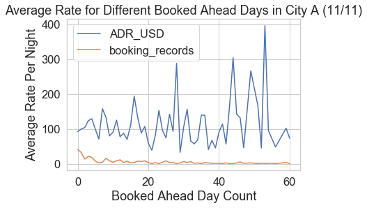

```python
book_ahead_h_1111 = plt.figure(figsize=(8, 6))
exA_veterans_11_ahead_ADR[['ADR_USD', 'booking_records']].plot(kind = "line")
plt.xlabel("Booked Ahead Day Count")
plt.ylabel("Average Rate Per Night");
plt.title("Average Rate for Different Booked Ahead Days in City A (11/11)")
book_ahead_h_1111.savefig('Pictures/book_ahead_h_1111.png')

# ['ADR_USD', 'booking_records']
```

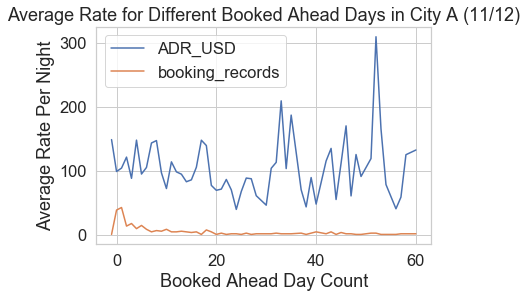

```python
book_ahead_h_1112 = plt.figure(figsize=(8, 6))
exA_veterans_12_ahead_ADR[['ADR_USD', 'booking_records']].plot(kind = "line")
plt.xlabel("Booked Ahead Day Count")
plt.ylabel("Average Rate Per Night");
plt.title("Average Rate for Different Booked Ahead Days in City A (11/12)")
book_ahead_h_1112.savefig('Pictures/book_ahead_h_1112.png')
```

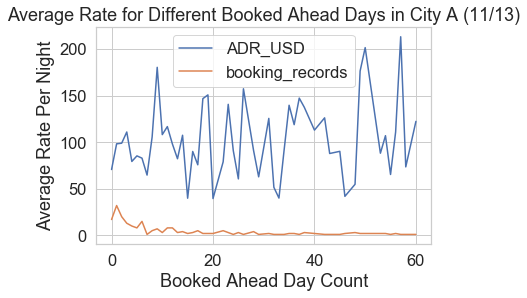

```python
book_ahead_h_1113 = plt.figure(figsize=(8, 6))
exA_veterans_13_ahead_ADR[['ADR_USD', 'booking_records']].plot(kind = "line")
plt.xlabel("Booked Ahead Day Count")
plt.ylabel("Average Rate Per Night");
plt.title("Average Rate for Different Booked Ahead Days in City A (11/13)")
book_ahead_h_1113.savefig('Pictures/book_ahead_h_1113.png')
```